# CORD-19 TF-IDF Complete Notebook

This notebook is my contribution to the Kaggle competition : [COVID-19 Open Research Dataset Challenge (CORD-19)](https://www.kaggle.com/allen-institute-for-ai/CORD-19-research-challenge)

The dataset is composed of 29 327 scientific articles which are to be processed in order to find information about some *'tasks'* (like : - *'Range of incubation periods for the disease in humans (and how this varies across age and health status) and how long individuals are contagious, even after recovery.'*), without, obviously, having to read all the documents.

**Features**

- Plots in 2-Dimensions of the text dataset with clustering
- Search of the most approriate sentences / documents for every tasks
- Free text search

**Implementation**

The ultimate goal of this notebook is to create a `Bokeh` Dashboard with every of those features.

**Text Representation**

In this notebook, the modelisation of the text is based on TF-IDF.

For Word-Embeddings based techniques, please see my other notebook in this repo and don't hesitate to compare the results.

**Main ideas and steps**

- **Firstly:**
  - TFIDF cosine similarity to find the most accurate sentences
  - Retrieving of the original document (to not have the sentences in an unreadable way)
- **Then** :
  - Indexing the sentences
  - Preprocessing/tfidf to find the indexes of the sentences which are relevant.
  - Picking a few from their scores (the 3/5 best ones, or the ones above a similarity score given a threshold, or both options combined together)

**To perform a better visualization of the documents** :

- PCA / LDA or t-SNE
- K-means to make clusters
- Chi-2 scores to see the most relevant words for each cluster

**We could even make a button next to an article to see its position compared to others**

## Loading packages

```python
### Dealing with the DataFrame:
import pandas as pd

#numpy:
import numpy as np

#Type:
import string
import ast

#Sklearn - ML:
from sklearn.feature_extraction.text import TfidfVectorizer
from sklearn.metrics.pairwise import linear_kernel
from sklearn.cluster import KMeans

#text preprocessing:
import nltk
from normalise import normalise
from nltk.tokenize import word_tokenize
import spacy
import re

#Saving and Loading variables:
import pickle

#Representation and Dimensionnality reduction:
from sklearn.decomposition import TruncatedSVD
from sklearn.decomposition import PCA
from sklearn.manifold import TSNE

#To find the associated grams to a cluster:
from sklearn.feature_selection import chi2

#Dealing with the visualization:
import seaborn as sns
import matplotlib.pyplot as plt
from IPython.display import HTML

#Dashboarding with bokeh:
from bokeh.plotting import figure
from bokeh.io import output_notebook, show
from bokeh.io import curdoc
from bokeh.models import Select, Column, RangeSlider, TapTool, OpenURL, Row, Div, Slider, Button,CheckboxButtonGroup, CheckboxGroup
from bokeh.models import AutocompleteInput, TextInput, ColumnDataSource, HoverTool
from bokeh.models import Panel, Tabs
from bokeh.layouts import column
from bokeh.palettes import Category10
from bokeh.transform import linear_cmap
output_notebook()
```

## Loading and exploring data :

We have the first dataset of articles, without preprocessing.

```python
df_covid=pd.read_csv('Data/cord19_df.csv')
```

```python
df_covid.head()
```

|  | paper_id | body_text | source_x | title | doi | pmcid | pubmed_id | license | abstract | publish_time | authors | journal | Microsoft Academic Paper ID | WHO #Covidence | has_full_text | full_text_file | publish_year | link | language | language_score |
| --- | --- | --- | --- | --- | --- | --- | --- | --- | --- | --- | --- | --- | --- | --- | --- | --- | --- | --- | --- | --- |
| 0 | 0015023cc06b5362d332b3baf348d11567ca2fbb | VP3, and VP0 (which is further processed to VP... | biorxiv | The RNA pseudoknots in foot-and-mouth disease ... | 10.1101/2020.01.10.901801 | NaN | NaN | biorxiv | The positive stranded RNA genomes of picornavi... | 2020-01-11 | Ward, J. C. J.; Lasecka-Dykes, L.; Neil, C.; A... | NaN | NaN | NaN | True | biorxiv_medrxiv | 2020 | http://dx.doi.org/10.1101/2020.01.10.901801 | en | 0.999996 |
| 1 | 004f0f8bb66cf446678dc13cf2701feec4f36d76 | The 2019-nCoV epidemic has spread across China... | medrxiv | Healthcare-resource-adjusted vulnerabilities t... | 10.1101/2020.02.11.20022111 | NaN | NaN | medrvix | We integrate the human movement and healthcare... | 2020-02-12 | Hanchu Zhou; Jianan Yang; Kaichen Tang; Qingpe... | NaN | NaN | NaN | True | biorxiv_medrxiv | 2020 | http://dx.doi.org/10.1101/2020.02.11.20022111 | en | 0.999996 |
| 2 | 00d16927588fb04d4be0e6b269fc02f0d3c2aa7b | Infectious bronchitis (IB), which is caused by... | biorxiv | Real-time, MinION-based, amplicon sequencing f... | 10.1101/634600 | NaN | NaN | biorxiv | Infectious bronchitis (IB) causes significant ... | 2019-05-10 | Butt, S. L.; Erwood, E. C.; Zhang, J.; Sellers... | NaN | NaN | NaN | True | biorxiv_medrxiv | 2019 | http://dx.doi.org/10.1101/634600 | en | 0.857140 |
| 3 | 0139ea4ca580af99b602c6435368e7fdbefacb03 | Nipah is an infectious negative-sense single-s... | biorxiv | A Combined Evidence Approach to Prioritize Nip... | 10.1101/2020.03.12.977918 | NaN | NaN | biorxiv | AbstractBackgroundNipah Virus (NiV) came into ... | 2020-03-12 | Nishi Kumari; Ayush Upadhyay; Kishan Kalia; Ra... | NaN | NaN | NaN | True | biorxiv_medrxiv | 2020 | http://dx.doi.org/10.1101/2020.03.12.977918 | en | 0.999997 |
| 4 | 013d9d1cba8a54d5d3718c229b812d7cf91b6c89 | In December 2019, a cluster of patients with p... | medrxiv | Assessing spread risk of Wuhan novel coronavir... | 10.1101/2020.02.04.20020479 | NaN | NaN | medrvix | Background: A novel coronavirus (2019-nCoV) em... | 2020-02-05 | Shengjie Lai; Isaac Bogoch; Nick Ruktanonchai;... | NaN | NaN | NaN | True | biorxiv_medrxiv | 2020 | http://dx.doi.org/10.1101/2020.02.04.20020479 | en | 0.999996 |

We have the second dataset, with body text, title and abstract preprocessed, and with sentence indexing and preprocessing procedures, in order to avoid running it every time a search is performed. This increases the size of the dataset but deeply reduces the computanional time.

As explained in the preprocessing part of this notebook, the preprocessing procedures were done in a python script, allowing multiprocessing to increase speed.

```python
df_preprocessed_covid=pd.read_csv('Data/df_covid_preprocessed.csv')
```

```python
df_preprocessed_covid.head()
```

|  | paper_id | body_text | source_x | title | doi | pmcid | pubmed_id | license | abstract | publish_time | ... | Microsoft Academic Paper ID | WHO #Covidence | has_full_text | full_text_file | publish_year | link | language | language_score | list_sentences | list_preprocessed_sentences |
| --- | --- | --- | --- | --- | --- | --- | --- | --- | --- | --- | --- | --- | --- | --- | --- | --- | --- | --- | --- | --- | --- |
| 0 | 0015023cc06b5362d332b3baf348d11567ca2fbb | vp3 vp0 process vp2 vp4 virus assembly 6 p2 64... | biorxiv | rna pseudoknot foot mouth disease virus dispen... | 10.1101/2020.01.10.901801 | NaN | NaN | biorxiv | positive strand rna genome picornavirus compri... | 2020-01-11 | ... | NaN | NaN | True | biorxiv_medrxiv | 2020 | http://dx.doi.org/10.1101/2020.01.10.901801 | en | 0.999996 | ['VP3, and VP0 (which is further processed to ... | ['vp3 vp0 process vp2 vp4 virus assembly 6', '... |
| 1 | 004f0f8bb66cf446678dc13cf2701feec4f36d76 | 2019-ncov epidemic spread china 24 country 1 3... | medrxiv | healthcare resource adjust vulnerability 2019 ... | 10.1101/2020.02.11.20022111 | NaN | NaN | medrvix | integrate human movement healthcare resource d... | 2020-02-12 | ... | NaN | NaN | True | biorxiv_medrxiv | 2020 | http://dx.doi.org/10.1101/2020.02.11.20022111 | en | 0.999996 | ['The 2019-nCoV epidemic has spread across Chi... | ['2019-ncov epidemic spread china 24 country 1... |
| 2 | 00d16927588fb04d4be0e6b269fc02f0d3c2aa7b | infectious bronchitis ib cause infectious bron... | biorxiv | real time minion base amplicon sequence lineag... | 10.1101/634600 | NaN | NaN | biorxiv | infectious bronchitis ib cause significant eco... | 2019-05-10 | ... | NaN | NaN | True | biorxiv_medrxiv | 2019 | http://dx.doi.org/10.1101/634600 | en | 0.857140 | ['Infectious bronchitis (IB), which is caused ... | ['infectious bronchitis ib cause infectious br... |
| 3 | 0139ea4ca580af99b602c6435368e7fdbefacb03 | nipah infectious negative sense single strand ... | biorxiv | combine evidence approach prioritize nipah vir... | 10.1101/2020.03.12.977918 | NaN | NaN | biorxiv | abstractbackgroundnipah virus niv come limelig... | 2020-03-12 | ... | NaN | NaN | True | biorxiv_medrxiv | 2020 | http://dx.doi.org/10.1101/2020.03.12.977918 | en | 0.999997 | ['Nipah is an infectious negative-sense single... | ['nipah infectious negative sense single stran... |
| 4 | 013d9d1cba8a54d5d3718c229b812d7cf91b6c89 | december 2019 cluster patient pneumonia unknow... | medrxiv | assess spread risk wuhan novel coronavirus chi... | 10.1101/2020.02.04.20020479 | NaN | NaN | medrvix | background novel coronavirus 2019-ncov emerge ... | 2020-02-05 | ... | NaN | NaN | True | biorxiv_medrxiv | 2020 | http://dx.doi.org/10.1101/2020.02.04.20020479 | en | 0.999996 | ['In December 2019, a cluster of patients with... | ['december 2019 cluster patient pneumonia unkn... |

5 rows × 22 columns

### General informations :

#### columns and types:

We can observe below the columns of the dataset with the corresponding types.

```python
df_covid.info()
```

```
<class 'pandas.core.frame.DataFrame'>
RangeIndex: 29327 entries, 0 to 29326
Data columns (total 20 columns):
paper_id                       29327 non-null object
body_text                      29327 non-null object
source_x                       27690 non-null object
title                          27646 non-null object
doi                            27380 non-null object
pmcid                          12078 non-null object
pubmed_id                      20822 non-null float64
license                        27690 non-null object
abstract                       25688 non-null object
publish_time                   27618 non-null object
authors                        26940 non-null object
journal                        26796 non-null object
Microsoft Academic Paper ID    297 non-null float64
WHO #Covidence                 423 non-null object
has_full_text                  27690 non-null object
full_text_file                 27690 non-null object
publish_year                   29327 non-null int64
link                           27380 non-null object
language                       29327 non-null object
language_score                 29327 non-null float64
dtypes: float64(3), int64(1), object(16)
memory usage: 4.5+ MB
```

#### Language detection:

With Spacy, I was able to detect the language of each article.

This information has been attached to both `df_covid` and `df_preprocessed_covid` DataFrames.

Firstly, we can show which languages are present in the dataset, as well as the proportion of each language.

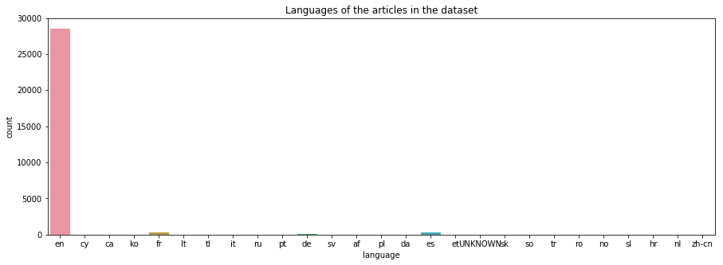

```python
#Definition of the figure:
plt.figure(figsize=(15,5))
#countplot:
sns.countplot(df_covid['language'])
plt.title('Languages of the articles in the dataset')
plt.show()
```

```python
df_covid[df_covid['language']!='en'].shape[0]
```

```
803
```

We can see that the majority of the articles are in English, but that a lot of languages are also present, including French and Spanish.

On the 29327 articles, 803 are not in English.

Because of the way the textical data is handled, I think it makes more sense to delete the non-english languages.

```python
df_covid=df_covid[df_covid['language']=='en']
df_preprocessed_covid=df_preprocessed_covid[df_preprocessed_covid['language']=='en']
```

```python
df_covid.shape
```

```
(28524, 20)
```

```python
df_preprocessed_covid.shape
```

```
(28524, 22)
```

#### Years of publication

We can also show the years of publication of the articles:

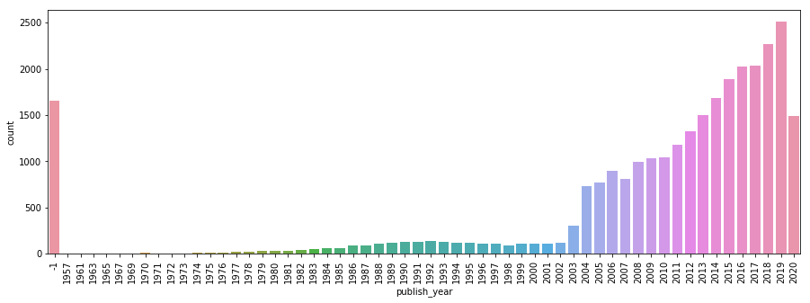

```python
fig = plt.figure(figsize=(15,5))
sns.countplot(df_covid.publish_year)
plt.xticks(rotation='vertical')
plt.show()
```

'-1' being the data loaded when the year is unknown, we can clearly see that most of the artciles were written in the last ten years.

#### Has full text ?

We can verify if articles have full or partial body text, since there is a column with that information in the dataset.

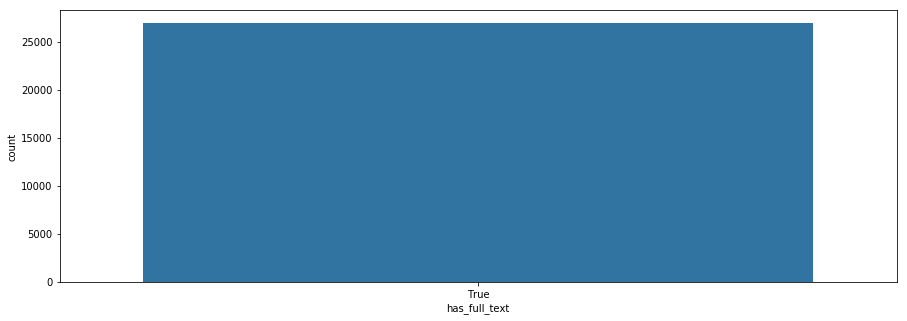

```python
fig=plt.figure(figsize=(15,5))
sns.countplot(df_covid.has_full_text)
```

#### Length of the body text of the articles

```python
Len=[]
for i in df_covid.body_text:
    Len.append(len(i))
```

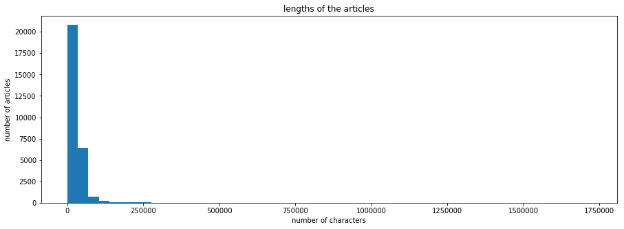

```python
plt.figure(figsize=(15,5))
plt.title('lengths of the articles')
plt.hist(Len,bins=50)
plt.xlabel('number of characters')
plt.ylabel('number of articles')
plt.show()
```

We can clearly see that the majority of the articles have a length under 200 000 characters.

```python
Len=np.array(Len)
len(Len[Len>1500000])
```

```
5
```

There are 5 articles with a length higher than 1 500 000. This can be an issue when loaded and processed with Spacy.

We can show their respective length below:

```python
d={'lengths':Len}
Lengths=pd.DataFrame(data=d)
Lengths[Lengths>1500000].dropna()
```

|  | lengths |
| --- | --- |
| 16012 | 1722585.0 |
| 16249 | 1634577.0 |
| 16476 | 1566439.0 |
| 23029 | 1529937.0 |
| 23898 | 1549213.0 |

## Preprocessing data :

In order to clean our dataset, we are going to :

- lemmatize the text
- remove stop words

I could have used already implemented functions, but to have complete control over the procedures implemented to format the text, I have written a custom function, with the help of [this](https://www.kaggle.com/balatmak/text-preprocessing-steps-and-universal-pipeline) and [this](https://towardsdatascience.com/text-preprocessing-steps-and-universal-pipeline-94233cb6725a).

There are several steps, including:

- Normalization
- removing the punctuation
- removing stop words
- lemmatize the text

```python
#Defining the global variable
global spacy_nlp
#Loading the english model of Spacy
spacy_nlp = spacy.load('en_core_web_sm')

def normalize(text):
    #function to normalize the text using the normalise package
    # some issues in normalise package
    try:
        return ' '.join(normalise(text,tokenizer=word_tokenize,verbose=False))
    except:
        return text

def remove_punct(doc):
    #Function to remove punctation
    return [t for t in doc if t.text not in string.punctuation]

def remove_stop_words(doc):
    #Function to remove stopwords
    return [t for t in doc if not t.is_stop]

def lemmatize(doc):
    #Function to lemmatize the articles
    return ' '.join([t.lemma_ for t in doc])

def preprocessing_part(text):
    #Function applying every other functions written above
    normalized_text=normalize(text).lower()
    doc=spacy_nlp(normalized_text)
    removed_punct=remove_punct(doc)
    removed_stop_words=remove_stop_words(removed_punct)
    return lemmatize(removed_stop_words)
```

### Applying to the CORD-19 dataset:

I already applied this function to the complete dataset in a .py file, using multithreading to increase speed and efficiency.

## Functions to retrieve information:

In this part of the notebook, I have written several functions, all based on a TF-IDF representation of the text, to retrieve information about the articles.

Some functions permits to find similar articles from another, given its index, and to export results in html, to be used in the Bokeh Dashboard described at the end of the notebook.

Some other functions do quite the same things, but with either a free text entry or a query as defined in the kaggle tasks.

At the end, a final function is implemented to do everything from one function.

#### Function to find similar documents from its index:

```python
def find_similar_from_index(tfidf_matrix, index, top_n = 5):
    """
    Function find_similar to find the similar documents of one given document, given its index in the corpus.

    @Inputs :
        - tfidf_matrix : matrix returned by the tfidf transformation of the entire corpus
        - index : the index of the document
        - top_n : the number of articles similar to be shown

    @Outputs :
        - indexes_scores_docs, a list with the indexes and the cosine similarity scores of the top n (top_n)
        most similar articles.
    """
    cosine_similarities = linear_kernel(tfidf_matrix[index:index+1], tfidf_matrix).flatten()
    related_docs_indices = [i for i in cosine_similarities.argsort()[::-1] if i != index]
    indexes_scores_docs = [(index, cosine_similarities[index]) for index in related_docs_indices][0:top_n]
    return indexes_scores_docs
```

#### Function to export the similar documents:

This function is used to export the results of the `find_similar_from_index` function in an html way, to be used in the Bokeh Dashboard.

```python
def print_similar_documents(df_covid, tfidf_matrix, index, top_n =5):
    #We firstly compute the indices and scores of the similar documents:
    indexes_scores_docs=find_similar_from_index(tfidf_matrix, index, top_n)
    #The we compute the html code to print results:
    h='<h3>Similar articles to : "<i>'+df_covid.iloc[index]['title']+'</i>"</h3>'
    for index_article, score_article in indexes_scores_articles:
        article=df_covid.iloc[index_article]
        title=str(article.title)
        #Link of the article:
        link=str(article.link)
        authors=str(article.authors)
        #We plot the general information about the article :
        h+='<ul> <li><a href="'+link+'" target="_blank">'+title+'</a>, by '+ authors +',  (Similarity Score: ' + "{:.2f}".format(score_article) + ')</li></ul>'
    return h
```

#### Function to find documents similar to a given query, and making the transformation :

```python
def find_documents_from_query(tfidf_matrix, tfidf_query, top_n=5):
    """
    Function find_documents_from_query, which computes the top_n most relevent articles given the tfidf representation
    of the query

    @Inputs:
    - tfidf_matrix, the tfidf matrix representation of the entire set of articles
    - tfidf_query, the tfidf vector representation of the query
    - top_n = 5, the number of documents to find
    @Outputs:
    indexes_scores, the index of each top_n article in the DataFrame, and the associated cosine_similarity score
    """
    #We calculate the cosine similarity between the query and each document:
    cosine_similarities = linear_kernel(tfidf_query, tfidf_matrix).flatten()
    #We sort the documents from the similarit to the query :
    related_docs_indices = [i for i in cosine_similarities.argsort()[::-1]]
    #We retrieve the top n documents most similar to the given query :
    indexes_scores = [(index, cosine_similarities[index]) for index in related_docs_indices][0:top_n]
    return indexes_scores
```

#### Function to export the sentences most relevent from each article :

For this purpose, we need to :

- index each sentences of the given articles
- perform TF-IDF on the set of sentences
- Compare the query with each sentence using cosine similarity

For the last task, we can easily use the function `find_similar`, just like before.

If we perform reduction on the documents to plot each documents with the distance to the other, we could also do the same with the sentences.

- Then, we show the relevent sentences, given a criteria :
  - We can use a threshold on the similarity score
  - We can also use a number of sentences to show, but this could end up showing sentences completely out of context

Therefore, I think we can use both.

**Warning** :

We must index the sentences before making any transformation to the text !!!

To avoid empty sentences (with the lemmatisation), we can show either a number of characters or sentences before and after the one chosen.

We can also verify that two sentences are not one after the other.

##### Function to index the sentences of an article:

I use the method descibed [here](https://medium.com/@makcedward/nlp-pipeline-sentence-tokenization-part-6-86ed55b185e6) to index the sentences of the articles:

```python
def sentence_indexing(article):
    """
    Function sentence_indexing made to index the sentences of an article

    @Inputs:
    article, the text of the article

    @Outputs:
    df_sentences, a pandas DataFrame, with a single column 'sentences', corresponding to each sentences of the article
                    Obviously, the indexing is then performed directly in the pandas DataFrame.
    """
    #We split the article for each '.' encountered, this gives every sentences of the text, which we then store in the
    #Pandas DataFrame 'df_sentences'.
    #We also verify that the sentences are not empty (because of a typo or because of the lemmatization)
    #df_sentences=pd.DataFrame({'sentences': [sentence for sentence in article.split('.') if sentence !='']})


    doc=spacy_nlp(article)
    df_sentences=pd.DataFrame({'sentences':[sentence.text for sentence in doc.sents]})

    return df_sentences
```

As explained before, since this kind of task can be very long, I performed this preprocessing before and stored it in `df_preprocessed_covid`. This aims at reducing the computational time.

##### Function to find the sentences most relevant for each article found :

```python
def index_relevant_sentences(df_preprocessed_covid, tfidf, index_article, tfidf_query, top_n_sentences=5):
    """
    Function relevant_sentences, which computes for a given query the most relevant sentences inside an article.

    @Inputs:
    df_preprocessed_covid
    tfidf, the tfidf model
    index_article, the index of the article
    tfidf_query, the given query, transformed after tfidf
    top_n_sentences

    @Outputs :
    index_score, the index and the score of the most relevant sentences (sorted)
    """
    d={'sentences':df_preprocessed_covid.iloc[index_article]['list_preprocessed_sentences']}
    df_preprocessed_sentences=pd.DataFrame(data=d)
    #We transform the sentences with tfidf:
    article_sentences_tfidf = tfidf.transform(df_preprocessed_sentences['sentences'])
    #We find the most relevant articles given the query, using find_document:
    index_scores = find_documents_from_query(article_sentences_tfidf, tfidf_query, top_n_sentences)
    return index_scores
```

The operations described in the last functions can return a list inside a string, and not directly a valid list.

In order to be able to compute the lists, we need to use `ast` and `literal_eval`.

```python
df_preprocessed_covid['list_preprocessed_sentences']=df_preprocessed_covid['list_preprocessed_sentences'].apply(ast.literal_eval)
df_preprocessed_covid['list_sentences']=df_preprocessed_covid['list_sentences'].apply(ast.literal_eval)
```

##### Function to transform the query with the tf-idf model :

```python
def transform_query(tfidf, query):
    """
    Function transform_query, which takes the tfidf model and a query, to preprocess it and transform it in a usable form
    @Inputs:
    tfidf, the tfidf model, fit on the entire corpus
    query, the given str query

    @Outputs:
    tfidf_query, the transformed query, after cleaning, preprocessing, lemmatization and tfidf transformation
    """
    preprocessed_query = preprocessing_part(query)
    tfidf_query = tfidf.transform([preprocessed_query]).toarray()
    return tfidf_query
```

##### Function to transform the entire text:

```python
def transform_text(df_preprocessed_covid, column='body_text'):
    """
    Function transform_text fitting the tfidf transformation and applying it to transform the articles
    @Inputs:
        - df_preprocessed_covid, the dataframe with the articles
        - column, the column in the dataframe concerned with this modification
    @Outputs:
        - tfidf, the tfidf model
        - tfidf_matrix, the tfidf matrix of the set of articles
    """
    df_preprocessed_covid[column] = df_preprocessed_covid[column].fillna(' ')
    # Initializing TFIDF :
    tfidf = TfidfVectorizer(sublinear_tf=True, min_df=5, norm='l2', encoding='latin-1', ngram_range=(1,1), max_features=10000)

    #Defining the features needed :
    tfidf_matrix = tfidf.fit_transform(df_preprocessed_covid[column]).toarray()
    return tfidf, tfidf_matrix
```

##### Executing tfidf and saving / loading the results

To avoid fitting and transforming data every time this notebook is opened, I use pickle to save the variables.

```python
#tfidf, tfidf_matrix = transform_text(df_preprocessed_covid, column='body_text')
#Saving:
#with open('pickle_save/tfidf_model_matrix.pickle', 'wb') as f:
#    pickle.dump([tfidf, tfidf_matrix], f)

#Loading:
with open('pickle_save/tfidf_model_matrix.pickle', 'rb') as f:
    tfidf, tfidf_matrix = pickle.load(f)
```

##### Final function, taking a query, transforming it, returning the most relevant articles and the most relevent sentences inside those articles

```python
def find_answers(df_covid, df_preprocessed_covid, query,tfidf=tfidf,tfidf_matrix=tfidf_matrix, column='body_text',top_n_sentences=5, top_n_articles=5):
    """
    Function find_answers to find the most relevent sentences inside the most relevant articles
    @Inputs:
        - df_covid, the DataFrame associated with the plain untransformed articles
        - df_preprocessed_covid, the DataFrame with the articles preprocessed (would be very long to perform this on each
            call of this function)
        - query, str, the plain query, to be transformed
        - tfidf, the tfidf model
        - tfidf_matrix, the tfidf matrix already computed
        - column, str, the text column to be processed
        - top_n_sentences : the number of sentences to select
        - top_n_articles : the number of articles to select

    @Outputs:
        - index_score_articles_sentences, a DataFrame, containing the indexes of the articles and the sentences of the
        articles, and the associated scores by cosine similarity
    """
    #Firstly, we compute empty lists to store indexes and scores:
    L_index_articles, L_index_sentences, L_scores_articles, L_scores_sentences= [],[],[],[]
    #We transform by tfidf the preprocessed dataset, selecting the needed column
    #tfidf, tfidf_matrix = transform_text(df_preprocessed_covid, column)
    #We transform the query :
    tfidf_query=transform_query(tfidf, query)
    #We want to find the most relevant articles for this query :
    #We compute the indexes of the relevant articles and their associated cosine similarity score
    indexes_scores_articles = find_documents_from_query(tfidf_matrix, tfidf_query, top_n=top_n_articles)
    #Since we have the indexes, we can have the articles, and find the sentences most relevent inside each article:
    for index_article, score_article in indexes_scores_articles:
        #Here, since we need to index the sentences of the articles, we take the df_covid, not preprocessed, DataFrame

        index_score_sentences=index_relevant_sentences(df_preprocessed_covid,tfidf,
                                                       index_article, tfidf_query, top_n_sentences)

        for index_sentence, score_sentence in index_score_sentences:
            #We store the wanted data in the associated lists:
            L_index_articles.append(index_article)
            L_index_sentences.append(index_sentence)
            L_scores_articles.append(score_article)
            L_scores_sentences.append(score_sentence)
    #Finally, we compute the DataFrame we want to return
    d={'index_article' : L_index_articles , 'score_article': L_scores_articles, 'index_sentence':  L_index_sentences,
       'score_sentence':L_scores_sentences }
    index_score_articles_sentences=pd.DataFrame(data=d)
    return index_score_articles_sentences
```

##### Verifying the results on a simple example:

We define one query:

```python
query='Range of incubation periods for the disease in humans (and how this varies across age and health status) and how long individuals are contagious, even after recovery'
```

We execute the `find_answers` function:

```python
%time index_score_articles_sentences=find_answers(df_covid, df_preprocessed_covid, query, column='body_text',top_n_sentences=5, top_n_articles=5)
```

```
Wall time: 1.51 s
```

```python
index_score_articles_sentences.head()
```

|  | index_article | score_article | index_sentence | score_sentence |
| --- | --- | --- | --- | --- |
| 0 | 20169 | 0.163448 | 9 | 0.342060 |
| 1 | 20169 | 0.163448 | 13 | 0.192125 |
| 2 | 20169 | 0.163448 | 18 | 0.157406 |
| 3 | 20169 | 0.163448 | 47 | 0.154767 |
| 4 | 20169 | 0.163448 | 24 | 0.131210 |

This seems suitable.

#### Function to export the results in a good and simple way:

What we want here is :

- the link to article
- the title
- the authors
- the source
- the sentences relevant
- the similarity scores with the query from cosine similarity
- the 2/3 most relevant sentences in the entire set.

```python
def compute_articles_sentences(index_score_articles_sentences, df_covid, h):
    """
    Function compute_articles_sentences which permits to store information about the most relevent articles
    and their associated relevent sentences """


    for index_article in index_score_articles_sentences['index_article'].unique():
        #We compute the score of the article:
        score_article=index_score_articles_sentences[index_score_articles_sentences['index_article']==index_article].score_article.iloc[0]
        #We compte the information about the article from the df_covid DataFrame with its associated index:
        article=df_covid.iloc[index_article]
        #Title of the article:
        title=str(article.title)
        #Link of the article:
        link=str(article.link)
        authors=str(article.authors)
        #We plot the general information about the article :
        h+='<br/><a href="'+link+'" target="_blank">'+title+'</a>, by '+ authors +',  (Similarity Score: ' + "{:.2f}".format(score_article) + ')'

        #We need to index the sentences of the article:
        d={'sentences':df_preprocessed_covid.iloc[index_article]['list_sentences']}
        df_sentences=pd.DataFrame(data=d)
        s=index_score_articles_sentences[index_score_articles_sentences['index_article']==index_article]
        index_sentences=s['index_sentence']
        for index_sentence in index_sentences:
            sentence=df_sentences.iloc[index_sentence]['sentences']
            score_sentence=s[s['index_sentence']==index_sentence]['score_sentence'].iloc[0]
            if score_sentence>0.01:
                h+='<ul> <li>' + sentence+ '. (Similarity score: '+ '{:.2f}'.format(score_sentence) +')</li></ul>'
    return h
```

```python
def compute_whole_answer(index_score_articles_sentences, df_covid, query, n_sentences=2):
    """
    Function compute_whole_answer to compute the entire response to a query.
    @Inputs:
    -index_score_articles_sentences
    -df_covid
    -query
    -n_sentences=2
    @Output:
    -h
    """
    h='<h3>Responses to the query : "<i>'+query+'</i>"</h3>'
    #Fisrtly, we compute the two most relevent sentences:
    h+='<h4> Most relevent sentences found : </h4>'
    #Computing them by sorting on the sentences scores:
    best_sentences=index_score_articles_sentences.sort_values(by=['score_sentence'], ascending=False)[:n_sentences]
    for index, b_sent in best_sentences.iterrows():
        index_article=b_sent['index_article'].astype(int)
        article=df_covid.iloc[index_article]




        d={'sentences':df_preprocessed_covid.iloc[index_article]['list_sentences']}
        df_sentences=pd.DataFrame(data=d)




        index_sentence=b_sent['index_sentence'].astype(int)
        score_sentence=b_sent['score_sentence']
        sentence=df_sentences.iloc[index_sentence]['sentences']
        h+='<ul><li>'+sentence+ '(Similarity score: '+ '{:.2f}'.format(score_sentence) +')</li></ul>'
    h+='<h4> Most relevent articles and the associated sentences : </h4>'
    h=compute_articles_sentences(index_score_articles_sentences, df_covid, h)
    return h
```

```python
%time h=compute_whole_answer(index_score_articles_sentences, df_covid, query)
```

```
Wall time: 148 ms
```

Computing the `compute_whole_answer` function is very fast.

We can now display the results of this function.

```python
display(HTML(h))
```

Responses to the query : "*Range of incubation periods for the disease in humans (and how this varies across age and health status) and how long individuals are contagious, even after recovery*"

Most relevent sentences found :

- Although the I-status is being treated in isolation, there are still many members of the E-status in the incubation period. (Similarity score: 0.39)

- The possible reason is that this isolation is only implemented for I-status users, but one of the characteristics of 2019-nCoV is that not only I-status is contagious, but E-status is also contagious.(Similarity score: 0.39)

Most relevent articles and the associated sentences :

[Epidemiology and disease control in everyday beef practice](http://dx.doi.org/10.1016/j.theriogenology.2008.04.011), by Larson, R.L., (Similarity Score: 0.16)

- www.theriojournal.com pathogen may not be very contagious, and a very contagious agent may not be highly virulent.. (Similarity score: 0.34)

- Other pathogens are spread only through sexual contact and are not contagious outside the act of mating.. (Similarity score: 0.19)

- Nutritional status such as adequate energy, protein, vitamins, and minerals impacts an animal's overall health and immune status.. (Similarity score: 0.16)

- Some infectious agents will infect all ages of cattle, but are only likely to cause disease in certain ages.. (Similarity score: 0.15)

- When we investigate a disease, we almost always consider the animal side of the infectious disease interaction, because the incubation period (interval from infection to onset of clinical signs), the symptomatic period (interval from onset to end of clinical signs), and non-diseased state (interval after the end of clinical signs) are relatively visible and measurable.. (Similarity score: 0.13)

[Beware of asymptomatic transmission: Study on 2019-nCoV prevention and control measures based on extended SEIR model](http://dx.doi.org/10.1101/2020.01.28.923169), by Shao, P.; Shan, Y., (Similarity Score: 0.16)

- Although the I-status is being treated in isolation, there are still many members of the E-status in the incubation period. . (Similarity score: 0.39)

- The possible reason is that this isolation is only implemented for I-status users, but one of the characteristics of 2019-nCoV is that not only I-status is contagious, but E-status is also contagious.. (Similarity score: 0.39)

- The Exposed status (E) may be transformed into an infected status (I) after the incubation period. . (Similarity score: 0.37)

- These individuals may have changed to the E-status because they had been in the same space with the I-status individuals. . (Similarity score: 0.32)

- This article suggests that as long as medical resources are available, E-status individuals or potential E-status individuals should be included in the scope of isolation and treatment.. (Similarity score: 0.26)

[The influenza pandemic preparedness planning tool InfluSim](http://dx.doi.org/10.1186/1471-2334-7-17), by Eichner, Martin; Schwehm, Markus; Duerr, Hans-Peter; Brockmann, Stefan O, (Similarity Score: 0.14)

- ,n of the incubation period. . (Similarity score: 0.38)

- After passing through the last incubation stage, infected individuals become fully contagious and a fraction of them develops clinical symptoms.. (Similarity score: 0.37)

- Passing through the incubation and contagious period is modelled in several stages which allows for realistic distributions of the sojourn times ( Table 4 ).. (Similarity score: 0.35)

- Child care at home also increases the exposure of healthy children (age a s ) to contagious adults (age. (Similarity score: 0.30)

- The last two stages of the incubation period are used as early infectious period during which the patient can already spread the disease.. (Similarity score: 0.28)

nan, by nan, (Similarity Score: 0.13)

- Age and sex had no associations with incubation period. . (Similarity score: 0.30)

- To determine the association between incubation period and severity of disease, we first estimated the difference in mean incubation period between patients who died and those who survived.. (Similarity score: 0.26)

- For the subset of patients without available exposure data, we assumed that their incubation time was 0-21 days because 21 days was the longest incubation period reported (9, 10) .. (Similarity score: 0.24)

- In a previous study, we found that the length of incubation period in patients infected with SARS coronavirus was also correlated with severity of the disease, with a shorter incubation period for patients who died (9) .. (Similarity score: 0.24)

- Incubation periods vary from person to person, and their distribution tends to be right-skewed and unimodal (3) .. (Similarity score: 0.24)

[Estimation of incubation period distribution of COVID-19 using disease onset forward time: a novel cross-sectional and forward follow-up study](http://dx.doi.org/10.1101/2020.03.06.20032417), by Qin Jing; Chong You; Qiushi Lin; Taojun Hu; Shicheng Yu; Xiao-Hua Zhou, (Similarity Score: 0.13)

- This may lead to an underestimation of the incubation period.. (Similarity score: 0.34)

- Compared with results in other studies, the incubation period estimated in this study is longer. . (Similarity score: 0.32)

- Quarantine of individuals with exposure to infectious pathogens has always been an effective approach for containing contagious diseases in the past.. (Similarity score: 0.31)

- Hence it is less likely we missed those patients with longer incubation periods based on the largest incubation period of 24 days reported in Guan et al. 4 Note that the 24-day incubation period was reported as an outlier in Guan et al.. (Similarity score: 0.25)

- We explore the sensitivity of estimates of incubation period by assuming a range of π , that is π ൌ 0 , 0 . . (Similarity score: 0.25)

## Defining the tasks:

We define every tasks, as described in the kaggle challenge.

```python
task1 = ["Range of incubation periods for the disease in humans (and how this varies across age and health status) and how long individuals are contagious, even after recovery.",
"Prevalence of asymptomatic shedding and transmission (e.g., particularly children).",
"Seasonality of transmission.",
"Physical science of the coronavirus (e.g., charge distribution, adhesion to hydrophilic/phobic surfaces, environmental survival to inform decontamination efforts for affected areas and provide information about viral shedding).",
"Persistence and stability on a multitude of substrates and sources (e.g., nasal discharge, sputum, urine, fecal matter, blood).",
"Persistence of virus on surfaces of different materials (e,g., copper, stainless steel, plastic).",
"Natural history of the virus and shedding of it from an infected person",
"Implementation of diagnostics and products to improve clinical processes",
"Disease models, including animal models for infection, disease and transmission",
"Tools and studies to monitor phenotypic change and potential adaptation of the virus",
"Immune response and immunity",
"Effectiveness of movement control strategies to prevent secondary transmission in health care and community settings",
 "Effectiveness of personal protective equipment (PPE) and its usefulness to reduce risk of transmission in health care and community settings",
"Role of the environment in transmission"]

task2 = ['Data on potential risks factors',
'Smoking, pre-existing pulmonary disease',
'Co-infections (determine whether co-existing respiratory/viral infections make the virus more transmissible or virulent) and other co-morbidities',
'Neonates and pregnant women',
'Socio-economic and behavioral factors to understand the economic impact of the virus and whether there were differences.',
'Transmission dynamics of the virus, including the basic reproductive number, incubation period, serial interval, modes of transmission and environmental factors',
'Severity of disease, including risk of fatality among symptomatic hospitalized patients, and high-risk patient groups',
'Susceptibility of populations',
'Public health mitigation measures that could be effective for control']

task3 = ['Real-time tracking of whole genomes and a mechanism for coordinating the rapid dissemination of that information to inform the development of diagnostics and therapeutics and to track variations of the virus over time.',
'Access to geographic and temporal diverse sample sets to understand geographic distribution and genomic differences, and determine whether there is more than one strain in circulation. Multi-lateral agreements such as the Nagoya Protocol could be leveraged.',
'Evidence that livestock could be infected (e.g., field surveillance, genetic sequencing, receptor binding) and serve as a reservoir after the epidemic appears to be over.',
'Evidence of whether farmers are infected, and whether farmers could have played a role in the origin.',
'Surveillance of mixed wildlife- livestock farms for SARS-CoV-2 and other coronaviruses in Southeast Asia.',
'Experimental infections to test host range for this pathogen.',
'Animal host(s) and any evidence of continued spill-over to humans',
'Socioeconomic and behavioral risk factors for this spill-over',
'Sustainable risk reduction strategies']

task4 = ["Guidance on ways to scale up NPIs in a more coordinated way (e.g., establish funding, infrastructure and authorities to support real time, authoritative (qualified participants) collaboration with all states to gain consensus on consistent guidance and to mobilize resources to geographic areas where critical shortfalls are identified) to give us time to enhance our health care delivery system capacity to respond to an increase in cases.",
"Rapid design and execution of experiments to examine and compare NPIs currently being implemented. DHS Centers for Excellence could potentially be leveraged to conduct these experiments.",
"Rapid assessment of the likely efficacy of school closures, travel bans, bans on mass gatherings of various sizes, and other social distancing approaches.",
"Methods to control the spread in communities, barriers to compliance and how these vary among different populations..",
"Models of potential interventions to predict costs and benefits that take account of such factors as race, income, disability, age, geographic location, immigration status, housing status, employment status, and health insurance status.",
"Policy changes necessary to enable the compliance of individuals with limited resources and the underserved with NPIs.",
"Research on why people fail to comply with public health advice, even if they want to do so (e.g., social or financial costs may be too high).",
"Research on the economic impact of this or any pandemic. This would include identifying policy and programmatic alternatives that lessen/mitigate risks to critical government services, food distribution and supplies, access to critical household supplies, and access to health diagnoses, treatment, and needed care, regardless of ability to pay."]

task5 = ["Effectiveness of drugs being developed and tried to treat COVID-19 patients. Clinical and bench trials to investigate less common viral inhibitors against COVID-19 such as naproxen, clarithromycin, and minocyclinethat that may exert effects on viral replication.",
"Methods evaluating potential complication of Antibody-Dependent Enhancement (ADE) in vaccine recipients.",
"Exploration of use of best animal models and their predictive value for a human vaccine.",
"Capabilities to discover a therapeutic (not vaccine) for the disease, and clinical effectiveness studies to discover therapeutics, to include antiviral agents.",
"Alternative models to aid decision makers in determining how to prioritize and distribute scarce, newly proven therapeutics as production ramps up. This could include identifying approaches for expanding production capacity to ensure equitable and timely distribution to populations in need.",
"Efforts targeted at a universal coronavirus vaccine.",
"Efforts to develop animal models and standardize challenge studies",
"Efforts to develop prophylaxis clinical studies and prioritize in healthcare workers",
"Approaches to evaluate risk for enhanced disease after vaccination",
"Assays to evaluate vaccine immune response and process development for vaccines, alongside suitable animal models [in conjunction with therapeutics]"]
```

```python
task6 = ["Efforts to articulate and translate existing ethical principles and standards to salient issues in COVID-2019",
"Efforts to embed ethics across all thematic areas, engage with novel ethical issues that arise and coordinate to minimize duplication of oversight",
"Efforts to support sustained education, access, and capacity building in the area of ethics",
"Efforts to establish a team at WHO that will be integrated within multidisciplinary research and operational platforms and that will connect with existing and expanded global networks of social sciences.",
"Efforts to develop qualitative assessment frameworks to systematically collect information related to local barriers and enablers for the uptake and adherence to public health measures for prevention and control. This includes the rapid identification of the secondary impacts of these measures. (e.g. use of surgical masks, modification of health seeking behaviors for SRH, school closures)",
"Efforts to identify how the burden of responding to the outbreak and implementing public health measures affects the physical and psychological health of those providing care for Covid-19 patients and identify the immediate needs that must be addressed.",
"Efforts to identify the underlying drivers of fear, anxiety and stigma that fuel misinformation and rumor, particularly through social media."]

task7 = ["How widespread current exposure is to be able to make immediate policy recommendations on mitigation measures. Denominators for testing and a mechanism for rapidly sharing that information, including demographics, to the extent possible. Sampling methods to determine asymptomatic disease (e.g., use of serosurveys (such as convalescent samples) and early detection of disease (e.g., use of screening of neutralizing antibodies such as ELISAs).",
"Efforts to increase capacity on existing diagnostic platforms and tap into existing surveillance platforms.",
"Recruitment, support, and coordination of local expertise and capacity (public, private—commercial, and non-profit, including academic), including legal, ethical, communications, and operational issues.",
"National guidance and guidelines about best practices to states (e.g., how states might leverage universities and private laboratories for testing purposes, communications to public health officials and the public).",
"Development of a point-of-care test (like a rapid influenza test) and rapid bed-side tests, recognizing the tradeoffs between speed, accessibility, and accuracy.",
"Rapid design and execution of targeted surveillance experiments calling for all potential testers using PCR in a defined area to start testing and report to a specific entity. These experiments could aid in collecting longitudinal samples, which are critical to understanding the impact of ad hoc local interventions (which also need to be recorded).",
"Separation of assay development issues from instruments, and the role of the private sector to help quickly migrate assays onto those devices.",
"Efforts to track the evolution of the virus (i.e., genetic drift or mutations) and avoid locking into specific reagents and surveillance/detection schemes.",
"Latency issues and when there is sufficient viral load to detect the pathogen, and understanding of what is needed in terms of biological and environmental sampling.",
"Use of diagnostics such as host response markers (e.g., cytokines) to detect early disease or predict severe disease progression, which would be important to understanding best clinical practice and efficacy of therapeutic interventions.",
"Policies and protocols for screening and testing.",
"Policies to mitigate the effects on supplies associated with mass testing, including swabs and reagents.",
"Technology roadmap for diagnostics.",
"Barriers to developing and scaling up new diagnostic tests (e.g., market forces), how future coalition and accelerator models (e.g., Coalition for Epidemic Preparedness Innovations) could provide critical funding for diagnostics, and opportunities for a streamlined regulatory environment.",
"New platforms and technology (e.g., CRISPR) to improve response times and employ more holistic approaches to COVID-19 and future diseases.",
"Coupling genomics and diagnostic testing on a large scale.",
"Enhance capabilities for rapid sequencing and bioinformatics to target regions of the genome that will allow specificity for a particular variant.",
"Enhance capacity (people, technology, data) for sequencing with advanced analytics for unknown pathogens, and explore capabilities for distinguishing naturally-occurring pathogens from intentional.",
"One Health surveillance of humans and potential sources of future spillover or ongoing exposure for this organism and future pathogens, including both evolutionary hosts (e.g., bats) and transmission hosts (e.g., heavily trafficked and farmed wildlife and domestic food and companion species), inclusive of environmental, demographic, and occupational risk factors."]


task8 = ["Resources to support skilled nursing facilities and long term care facilities.",
"Mobilization of surge medical staff to address shortages in overwhelmed communities",
"Age-adjusted mortality data for Acute Respiratory Distress Syndrome (ARDS) with/without other organ failure – particularly for viral etiologies",
"Extracorporeal membrane oxygenation (ECMO) outcomes data of COVID-19 patients",
"Outcomes data for COVID-19 after mechanical ventilation adjusted for age.",
"Knowledge of the frequency, manifestations, and course of extrapulmonary manifestations of COVID-19, including, but not limited to, possible cardiomyopathy and cardiac arrest.",
"Application of regulatory standards (e.g., EUA, CLIA) and ability to adapt care to crisis standards of care level.",
"Approaches for encouraging and facilitating the production of elastomeric respirators, which can save thousands of N95 masks.",
"Best telemedicine practices, barriers and faciitators, and specific actions to remove/expand them within and across state boundaries.",
"Guidance on the simple things people can do at home to take care of sick people and manage disease.",
"Oral medications that might potentially work.",
"Use of AI in real-time health care delivery to evaluate interventions, risk factors, and outcomes in a way that could not be done manually.",
"Best practices and critical challenges and innovative solutions and technologies in hospital flow and organization, workforce protection, workforce allocation, community-based support resources, payment, and supply chain management to enhance capacity, efficiency, and outcomes.",
"Efforts to define the natural history of disease to inform clinical care, public health interventions, infection prevention control, transmission, and clinical trials",
"Efforts to develop a core clinical outcome set to maximize usability of data across a range of trials",
"Efforts to determine adjunctive and supportive interventions that can improve the clinical outcomes of infected patients (e.g. steroids, high flow oxygen)"]
```

```python
task9 = ["Methods for coordinating data-gathering with standardized nomenclature.",
"Sharing response information among planners, providers, and others.",
"Understanding and mitigating barriers to information-sharing.",
"How to recruit, support, and coordinate local (non-Federal) expertise and capacity relevant to public health emergency response (public, private, commercial and non-profit, including academic).",
"Integration of federal/state/local public health surveillance systems.",
"Value of investments in baseline public health response infrastructure preparedness",
"Modes of communicating with target high-risk populations (elderly, health care workers).",
"Risk communication and guidelines that are easy to understand and follow (include targeting at risk populations’ families too).",
"Communication that indicates potential risk of disease to all population groups.",
"Misunderstanding around containment and mitigation.",
"Action plan to mitigate gaps and problems of inequity in the Nation’s public health capability, capacity, and funding to ensure all citizens in need are supported and can access information, surveillance, and treatment.",
"Measures to reach marginalized and disadvantaged populations.",
"Data systems and research priorities and agendas incorporate attention to the needs and circumstances of disadvantaged populations and underrepresented minorities.",
"Mitigating threats to incarcerated people from COVID-19, assuring access to information, prevention, diagnosis, and treatment.",
"Understanding coverage policies (barriers and opportunities) related to testing, treatment, and care"]

tasks={'What is known about transmission, incubation, and environmental stability?': task1,
       'What do we know about COVID-19 risk factors?': task2,
       'What do we know about virus genetics, origin, and evolution?': task3,
       'What do we know about non-pharmaceutical interventions?': task4,
       'What do we know about vaccines and therapeutics?': task5,
       'What has been published about ethical and social science considerations?': task6,
       'What do we know about diagnostics and surveillance?': task7,
       'What has been published about medical care?': task8,
       'What has been published about information sharing and inter-sectoral collaboration?': task9}

task_name=list(tasks.keys())
```

## Dimensionnality reduction:

In order to plot our dataset in two dimensions, we have to use dimensionnality reduction.

We are going to use three dimensionnality reduction models :

- LSA
- PCA
- PCA + t-SNE

### [truncated SVD / LSA](https://scikit-learn.org/stable/modules/generated/sklearn.decomposition.TruncatedSVD.html) :

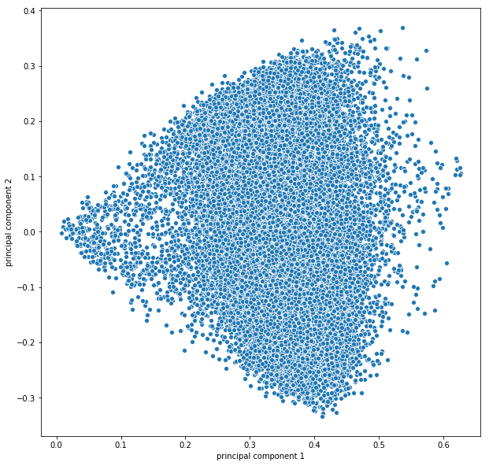

```python
#Defining the LSA model :
LSA = TruncatedSVD(n_components=2)
#Applying the model to the tfidf matrix :
principalComponents=LSA.fit_transform(tfidf_matrix)
#Defining the DataFrame associted with the LSA with both principal components
df_LSA = pd.DataFrame(data = principalComponents, columns = ['principal component 1', 'principal component 2'])
#Defining the figure :
fig=plt.figure(figsize=(10,10))
#Plot data:
sns.scatterplot(x=df_LSA['principal component 1'], y=df_LSA['principal component 2'], palette="muted")
plt.show()
```

### [PCA](https://scikit-learn.org/stable/modules/generated/sklearn.decomposition.PCA.html):

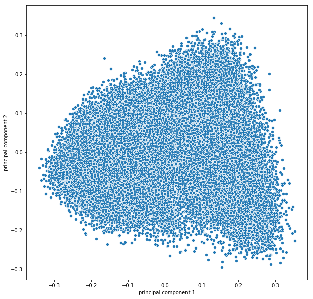

```python
#Defining the PCA model :
PCA_model = PCA(n_components=2)
#Applying the PCA model to the tfidf matrix
principalComponents=PCA_model.fit_transform(tfidf_matrix)
#Defining the DataFrame with both PCA principal Components
df_PCA = pd.DataFrame(data = principalComponents, columns = ['principal component 1', 'principal component 2'])
#Defining the figure :
fig=plt.figure(figsize=(10,10))
#Plot:
sns.scatterplot(x=df_PCA['principal component 1'], y=df_PCA['principal component 2'], palette="muted")
plt.show()
```

We can clearly see that LSA and PCA don't have the same principal components distribution.

We will investigate which one is better in out analysis, but before, we are going to try PCA with t-SNE.

### PCA + t-SNE

Reading the [sklearn documentation](https://scikit-learn.org/stable/modules/generated/sklearn.manifold.TSNE.html), it is highly recommended to use PCA before t-SNE.

This is also explained in [that](https://towardsdatascience.com/visualising-high-dimensional-datasets-using-pca-and-t-sne-in-python-8ef87e7915b) article.

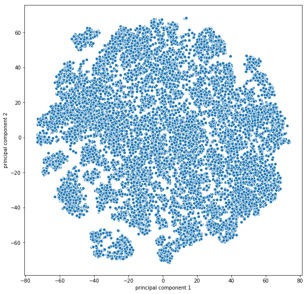

```python
#We firstly compute a Principal Component Analysis with 50 components
PCA_50 = PCA(n_components=50)
principalComponents50=PCA_50.fit_transform(tfidf_matrix)
#We then compute the t-SNE to have 2 principal components:
tsne_2 = TSNE(n_components=2)
principalComponents = tsne_2.fit_transform(principalComponents50)
#We compute the DataFrame:
df_PCA_tSNE = pd.DataFrame(data = principalComponents, columns = ['principal component 1', 'principal component 2'])
fig=plt.figure(figsize=(10,10))
sns.scatterplot(x=df_PCA_tSNE['principal component 1'], y=df_PCA_tSNE['principal component 2'], palette="muted")
plt.show()
```

Using PCA + t-SNE, we obtain quite a different 2D representation of our dataset.

We are later going to try - with clustering- to establish which representation is the greatest for our use.

## Clustering :

We are now going to use clustering to separate our data in several sets according to their properties.

In order to do so we are going to :

- Use k-means to cluster our dataset
- take the most correlated unigrams to add a more instructive legend to our clusters.

### K-means :

```python
#Defining the number of clusters :
number_clusters = 10
#Defining the k-means model:
kmeans = KMeans(n_clusters=number_clusters)
#using the model to define the clusters
labels = kmeans.fit_predict(tfidf_matrix)
#Defining the labels dataset :
data_labels={'cluster': labels}
df_labels=pd.DataFrame(data=data_labels)
```

### Taking the most correlated unigrams to get information about each cluster:

We can help ourselves with [that article](https://towardsdatascience.com/multi-class-text-classification-with-scikit-learn-12f1e60e0a9f) and this [scikit-learn documentation](http://scikit-learn.org/stable/modules/generated/sklearn.feature_selection.chi2.html).

We define the function `correlations_grams` below to obtain the result.

```python
def correlations_grams(tfidf_matrix, df, tfidf,column_label_name='cluster', N=2):
    """
    function to get the most correlated n-grams associated with each cluster
    @Inputs:
        - tfidf_matrix, the tf_idf matrix
        - df, Pandas DataFrame, the DataFrame with both principal component and one column with the indication on the cluster
        - tfidf, the tfidf model
        - n, int, the number unigrams to obtain
    @Output:
        Corresponding_Grams, the list of the wanted corresponding unigrams
    """
    labels=df[column_label_name]
    unique_labels=labels.unique()
    #We set up the list Corresponding_Grams that we want to return:
    Corresponding_Grams=[]
    for label in unique_labels:
        features_chi2 = chi2(tfidf_matrix, labels == label)
        indices = np.argsort(features_chi2[0])
        feature_names = np.array(tfidf.get_feature_names())[indices]
        unigrams = [v for v in feature_names if len(v.split(' ')) == 1]
        #We store the results:
        Corresponding_Grams.append(unigrams[-N:])
    return Corresponding_Grams
```

We can also define two other functions to be used in the definition of the Dashboard.

```python
def print_corresponding_grams(Corresponding_Grams):
    """
    function print_corresponding_grams to plot the corresponding grams to a label
    @Inputs:
    -Corresponding_Grams
    @Output:
    -h
    """
    h=''
    i=0
    for unigrams in Corresponding_Grams:
        h+="<h3>For the label : '{}':</h3>".format(i)
        h+="<h4>. Most correlated unigrams:</h4>{}".format('-'.join(unigrams))
        i+=1
    return h

def associate_corresponding_grams(Corresponding_Grams, df, column_label_name='cluster'):
    """
    Function associate_corresponding_grams which associates the grams most correlated with each cluster
    Please be careful, this function applies the transformation to the DataFrame in input.

    @Inputs:
    - Corresponding_Grams
    - df
    - column_label_name
    @Output:
    - df, the DataFrame
    """
    df['label_corresponding_name']=df[column_label_name]
    dictionnary={int(i) : str(Corresponding_Grams[i]) for i in range(len(Corresponding_Grams))}
    df['label_corresponding_name'].replace(dictionnary, inplace=True)
    return df
```

## Representation :

In this part of the notebook, we are going to establish which representation of the dataset fits our need, by plotting them with the labels of their respective cluster.

### Establishing which representation to use :

#### LSA + Clustering

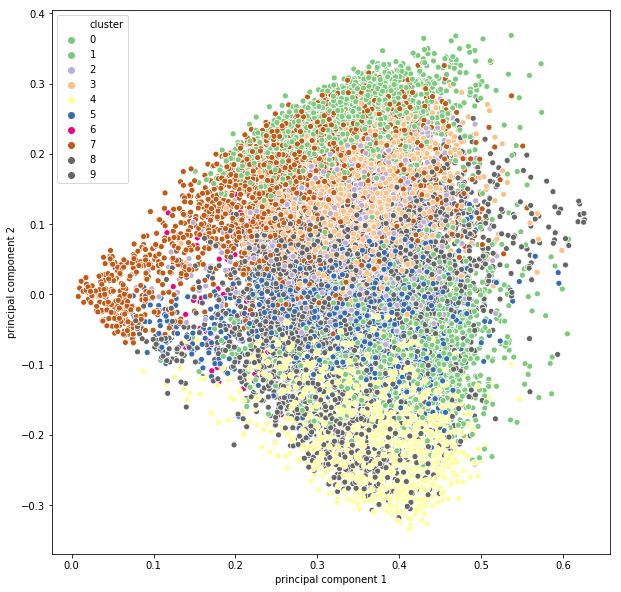

```python
df_LSA_Clustering = pd.concat([df_LSA, df_labels], axis = 1)
fig=plt.figure(figsize=(10,10))
sns.scatterplot(x=df_LSA_Clustering['principal component 1'], y=df_LSA_Clustering['principal component 2'],
                hue=df_LSA_Clustering.cluster, palette='Accent', legend='full')
plt.show()
```

#### PCA + Clustering

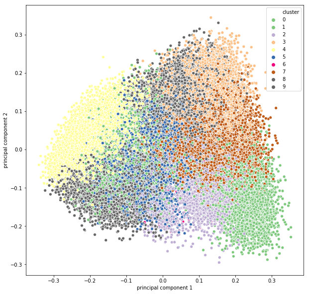

```python
df_PCA_Clustering = pd.concat([df_PCA, df_labels], axis = 1)
fig=plt.figure(figsize=(10,10))
sns.scatterplot(x=df_PCA_Clustering['principal component 1'], y=df_PCA_Clustering['principal component 2'],
                hue=df_PCA_Clustering.cluster, palette='Accent', legend='full')
plt.show()
```

#### PCA + t-SNE + Clustering

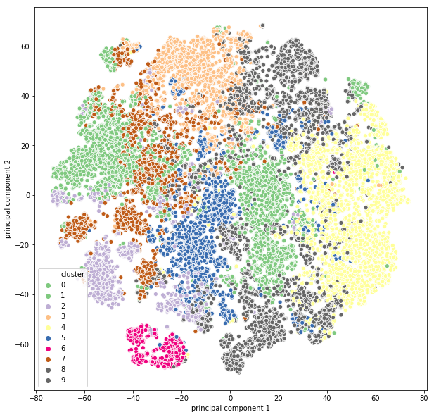

```python
df_PCA_tSNE_Clustering = pd.concat([df_PCA_tSNE, df_labels], axis = 1)
fig=plt.figure(figsize=(10,10))
sns.scatterplot(x=df_PCA_tSNE_Clustering['principal component 1'], y=df_PCA_tSNE_Clustering['principal component 2'],
                hue=df_PCA_tSNE_Clustering.cluster, palette='Accent', legend='full')
plt.show()
```

### Defining a function for dimensionnality reduction and clustering

```python
def reduction_clustering(tfidf_matrix, tfidf, number_clusters=10):
    """
    Function reduction_clustering to make both the reduction on a DataFrame and to cluster the data
    We use PCA for the reduction and Kmeans for the clustering part

    @Inputs:
    - tfidf_matrix
    - tfidf
    - number_clusters
    @Outputs:
    - finalDf, the DataFrame containg the wanted information.
        Column: 'principal component 1', the first coordinate by PCA
                'principal component 2', the second coordinate by PCA
                'cluster', the cluster of the row returned by KMeans
    - PCA, the trained PCA model
    - kmeans, the trained KMeans model
    - Corresponding_Grams
    """
    reduction_model = PCA(n_components=2)
    principalComponents=reduction_model.fit_transform(tfidf_matrix)
    df_reduction = pd.DataFrame(data = principalComponents, columns = ['principal component 1', 'principal component 2'])
    kmeans = KMeans(n_clusters=number_clusters)
    labels = kmeans.fit_predict(tfidf_matrix)
    data_labels={'cluster': labels}
    df_labels=pd.DataFrame(data=data_labels)
    finalDf = pd.concat([df_reduction, df_labels], axis = 1)
    Corresponding_Grams=correlations_grams(tfidf_matrix,finalDf,tfidf)
    finalDf=associate_corresponding_grams(Corresponding_Grams, finalDf)
    return finalDf, reduction_model, kmeans, Corresponding_Grams
```

Then, we can compute directly the dimensionnality reduction, the clustering algorithm, and the DataFrame associated with the data we want to obtain.

The lines after the computation of the function above permits to save the results and avoid executing it every time.

```python
#finalDf, PrincipalCA, kmeans, Corresponding_Grams = reduction_clustering(tfidf_matrix, tfidf)
#Saving:
#with open('pickle_save/final_Df_PCA_kmeans.pickle', 'wb') as f:
#    pickle.dump([finalDf, PrincipalCA, kmeans], f)

#Loading:
with open('pickle_save/final_Df_PCA_kmeans.pickle', 'rb') as f:
    finalDf, PrincipalCA, kmeans = pickle.load(f)
```

```python
#Saving:
#with open('pickle_save/corresponding_grams.pickle', 'wb') as f:
#    pickle.dump(Corresponding_Grams, f)

#Loading:
with open('pickle_save/corresponding_grams.pickle', 'rb') as f:
    Corresponding_Grams = pickle.load(f)
```

We can visualize the DataFrame after computing the `reduction_clustering` function

```python
finalDf.head()
```

|  | principal component 1 | principal component 2 | cluster | label_corresponding_name |
| --- | --- | --- | --- | --- |
| 0 | -0.103795 | -0.120857 | 9 | ['abdominal', 'abscess'] |
| 1 | 0.170649 | -0.105211 | 6 | ['innate', 'activation'] |
| 2 | -0.041523 | -0.064729 | 9 | ['abdominal', 'abscess'] |
| 3 | 0.022265 | -0.114598 | 8 | ['colostrum', 'calf'] |
| 4 | 0.223830 | -0.126412 | 9 | ['abdominal', 'abscess'] |

## Dashboard:

In this part of the notebook, we are defining the function used to plot all of our work in one interactive dashboard.

```python
#principalDf['abstract']=df_covid.abstract
finalDf['link']=df_covid.link
finalDf['title']=df_covid.title
finalDf['authors']=df_covid.authors
#principalDf.drop(['abstract'], axis=1, inplace=True)
finalDf['year']=df_covid.publish_year
```

```python
finalDf.head()
```

|  | principal component 1 | principal component 2 | cluster | label_corresponding_name | link | title | authors | year |
| --- | --- | --- | --- | --- | --- | --- | --- | --- |
| 0 | -0.103795 | -0.120857 | 9 | ['abdominal', 'abscess'] | http://dx.doi.org/10.1101/2020.01.10.901801 | The RNA pseudoknots in foot-and-mouth disease ... | Ward, J. C. J.; Lasecka-Dykes, L.; Neil, C.; A... | 2020.0 |
| 1 | 0.170649 | -0.105211 | 6 | ['innate', 'activation'] | http://dx.doi.org/10.1101/2020.02.11.20022111 | Healthcare-resource-adjusted vulnerabilities t... | Hanchu Zhou; Jianan Yang; Kaichen Tang; Qingpe... | 2020.0 |
| 2 | -0.041523 | -0.064729 | 9 | ['abdominal', 'abscess'] | http://dx.doi.org/10.1101/634600 | Real-time, MinION-based, amplicon sequencing f... | Butt, S. L.; Erwood, E. C.; Zhang, J.; Sellers... | 2019.0 |
| 3 | 0.022265 | -0.114598 | 8 | ['colostrum', 'calf'] | http://dx.doi.org/10.1101/2020.03.12.977918 | A Combined Evidence Approach to Prioritize Nip... | Nishi Kumari; Ayush Upadhyay; Kishan Kalia; Ra... | 2020.0 |
| 4 | 0.223830 | -0.126412 | 9 | ['abdominal', 'abscess'] | http://dx.doi.org/10.1101/2020.02.04.20020479 | Assessing spread risk of Wuhan novel coronavir... | Shengjie Lai; Isaac Bogoch; Nick Ruktanonchai;... | 2020.0 |

```python
def my_covid_app(doc):
    #We can make a function to indicate that a time consuming function is executing, via a gif in a div for exemple.
    def loading(name_div):
        #Insted of a gif image, we could use:
        #https://creativecommons.org/2017/12/07/one-week-left-save-internet/
        name_div.text="""<img src="Dashboard/images/loading_gif_white.gif" height="250" width="400"> </img>"""
    #---------------------------------------------------------------------------------------------------------#
    #---------------------------------------------------------------------------------------------------------#
    #---------------------------First TAB--------------------------------------------------------------------#
    #---------------------------------------------------------------------------------------------------------#
    #---------------------------------------------------------------------------------------------------------#

    #We define properly the source of data:
    source = ColumnDataSource(data=finalDf)

    #We define the entire plot for the first tab:
    p = figure(plot_width=600, plot_height=500,
               tools=["tap", "pan","wheel_zoom","box_zoom","reset"],
               title='PCA of the articles, clustering by k-means')


    #We need to map the colors :
    # map colors
    lower_cluster=min(finalDf['cluster'])
    higher_cluster=max(finalDf['cluster'])
    map_color = linear_cmap(field_name='cluster', palette=Category10[10], low=lower_cluster, high=higher_cluster)


    #We define the scatterplot with circle:
    p.circle('principal component 1', 'principal component 2', source=source,alpha=0.8,
                 muted_color=map_color, muted_alpha=0.2,
                 legend='cluster', fill_color=map_color, name='articles_rep')





    task_selection = Select(title="Task",options=task_name, value='What is known about transmission, incubation, and environmental stability?')
    query_selection= Select(title="Query of the selected task:",
                            options = list(tasks['What is known about transmission, incubation, and environmental stability?']),
                            value='Range of incubation periods for the disease in humans (and how this varies across age and health status) and how long individuals are contagious, even after recovery.')
    number_articles= Slider(title="Number of articles to show", start=0, end=10, step=1, value=5)
    number_sentences= Slider(title="Number of sentences per article to show", start=0, end=10, step=1, value=5)





    #RangeSlider to select years:
    min_year=1970
    max_year=max(finalDf['year'])
    slider_year=RangeSlider(start=min_year, end=max_year, value=(min_year, max_year),
                            step=1, title = 'Publish year range', width=200)



    #Checkbox to select (or not) even the unknown years:
    checkbox_year=CheckboxGroup(labels=["All years"], active=[0], width=150)



    def update_button_year():
        if "All years" in [checkbox_year.labels[i] for i in checkbox_year.active]:
            slider_year.value=(min_year,max_year)
            data=finalDf
            source.data=ColumnDataSource.from_df(data)
        else:
            scale = slider_year.value
            data=finalDf[finalDf['year'].between(scale[0],scale[1])]
            source.data=ColumnDataSource.from_df(data)

    def all_year_selection_checkbox(attr,old,new):
        if "All years" in [checkbox_year.labels[i] for i in checkbox_year.active]:
            slider_year.value=(min_year,max_year)

    def all_year_selection_slider(attr,old,new):
        if slider_year.value != (min_year, max_year):
            checkbox_year.active=[]
        else:
            checkbox_year.active=[0]


    validate_button_year=Button(label='Check visualization for the selected years', height=80)
    validate_button_year.on_click(update_button_year)

    # Attach the all_year_selection_slider callback to the 'value' property of slider_year
    slider_year.on_change('value', all_year_selection_slider)
    #We do the same and attach the all_year_selection_checkbox callback to the 'active' property of the checkbox_year
    checkbox_year.on_change('active',all_year_selection_checkbox)




    #We define the callback to update the query to the selected task:
    #https://stackoverflow.com/questions/56278118/python-how-to-dynamically-change-options-in-bokeh-select-widget
    def update_query(attr, old, new):
        task_selected = task_selection.value
        query_selection.options = list(tasks[task_selected])
        query_selection.value = list(tasks[task_selected])[0]




    #We plot the answers to the query:
    #the part "style={'overflow-y':'scroll', 'height':'350px'}" permits to not overflow the figure and the app
    query_selected=query_selection.value
    index_score_articles_sentences=find_answers(df_covid, df_preprocessed_covid, query_selected,
                                                    top_n_articles=number_articles.value,
                                                    top_n_sentences=number_sentences.value)
    h=compute_whole_answer(index_score_articles_sentences, df_covid, query_selected)
    div_html_response = Div(text=h, style={'overflow-y':'scroll', 'height':'350px', 'width':'350px'})


    #We define the callback function to update the answer to the selected query:
    def update_answer():
        #We take the value of the query:
        query_selected=query_selection.value



        index_score_articles_sentences=find_answers(df_covid, df_preprocessed_covid, query_selected,
                                                    top_n_articles=number_articles.value,
                                                    top_n_sentences=number_sentences.value)
        h=compute_whole_answer(index_score_articles_sentences, df_covid, query_selected)
        div_html_response.text=h
        #We update the representation of the query in the plot:
        update_representation_query()


    def loading_updating_answer(attr, old, new):
        #To be able to show that the work is in progress,
        #We use that : https://discourse.bokeh.org/t/show-loading-sign-during-calculations/4410
        #We indicate to the user that the app is searching for results:
        loading(div_html_response)
        curdoc().add_next_tick_callback(update_answer)
```

```python
    #We define the behaviour when the query is modified:
    query_selection.on_change('value', loading_updating_answer)
    #We also want that the query is updated when the task is modified.
    #We define the behaviour when the task is modified:
    #We have modified the function update_query accordingly.
    task_selection.on_change('value', update_query)







    #We want to change the responses with the numbers of articles and sentences selected in
    #the number_articles and number_sentences sliders
    number_articles.on_change('value', loading_updating_answer)
    number_sentences.on_change('value', loading_updating_answer)



    #--------------------------------------------------------------------Plotting the QUERY ----------------------#
    #We plot the query in the graph:
    query_coordinates= PrincipalCA.transform(transform_query(tfidf, query_selection.value))
    [[query_x, query_y]]=query_coordinates
    data_query = {'query_x': [query_x],'query_y': [query_y], 'query' : [query_selection.value]}
    source_rep_query=ColumnDataSource(data=data_query)
    p.circle(x='query_x', y='query_y', size=10,  fill_color="red", legend_label='Query',
             name='query_rep', source=source_rep_query)


    def update_representation_query():
        #We update the coordinates of the query:
        query_coordinates= PrincipalCA.transform(transform_query(tfidf, query_selection.value))
        [[new_query_x, new_query_y]]=query_coordinates
        new_data_query={'query_x': [new_query_x],'query_y': [new_query_y], 'query': [query_selection.value]}
        source_rep_query.data=new_data_query

    #-------------------------------------------------------------------------------------------------------------------------#
    #Legend behaviour:
    #Doc : https://docs.bokeh.org/en/latest/docs/user_guide/interaction/legends.html
    p.legend.location = "top_right"
    p.legend.click_policy="mute"


    #Hovers (one for the article points, the over for the query)
    #Tooltips for the hover definition on the representation of the articles:
    tooltips_articles = [("Title", "@title"),('Authors', "@authors"),("url", "@link"),("id", "@index")]
    #Tooltips for the hover definition on the query:
    tooltips_query=[("Your Query","@query")]
    #Defining the two hovers, with the corresponding names and tooltips:
    hover_article=HoverTool(names=['articles_rep'], tooltips=tooltips_articles)
    hover_query=HoverTool(names=['query_rep'], tooltips=tooltips_query)


    p.add_tools(hover_article)
    p.add_tools(hover_query)


    #We define the link of each glyph as the link column in the DataFrame
    url = "@link"
    taptool = p.select(type=TapTool)
    #We the user taps on a glyph (a circle associated with an article), the url is open
    taptool.callback = OpenURL(url=url)



    #We define the way to plot the different parts of the app:
    #We have the left part with the question-answering

    layout_left=Column(task_selection,query_selection,number_articles, number_sentences,div_html_response)

    #We have the right part with the PCA representation and the clustering.
    year_layout=Row(Column(checkbox_year,slider_year),validate_button_year)
    layout_right=Column(year_layout, p)
    #We define the entire layout:
    entire_layout1=Row(layout_left,layout_right)

    #---------------------------------------------------------------------------------------------------------#
    #---------------------------------------------------------------------------------------------------------#
    #---------------------------SECOND TAB--------------------------------------------------------------------#
    #-------------------------------FREE SEARCH---------------------------------------------------------------#
    #---------------------------------------------------------------------------------------------------------#

    free_search_input = TextInput(value="")
    validation_free_search=Button(label='Search')
    #We define the first results:
    div_results_free_search=Div(text="""Please enter your search in the input bar above and click on 'Search'
    <br/> The results can be quite long to be obtained so please be patient""",
        style={'overflow-y':'scroll', 'max-height':'600px', 'width':'900px'})
    #We define the button to show/hide the visualization of the query and the responses:
    free_visualization_button=Button(label='Show the visualization of your query')
    #We define the visualization of the query:

    #We define properly the source of data:
    source_tab2 = ColumnDataSource(data=finalDf)

    #We define the entire plot for the second tab:
    plot_2 = figure(plot_width=600, plot_height=500,
               tools=["tap", "pan","wheel_zoom","box_zoom","reset"],
               title='PCA of the articles, clustering by k-means', visible=False)
    #We define the scatterplot with circle:
    plot_2.circle('principal component 1', 'principal component 2', source=source_tab2,alpha=0.8,
                 muted_color=map_color, muted_alpha=0.2,
                 legend='cluster', fill_color=map_color, name='articles_rep')


    #--------------------------------------------------------------------Plotting the QUERY ----------------------#
    #We plot the query in the graph:
    query_coordinates= PrincipalCA.transform(transform_query(tfidf, free_search_input.value))
    [[query_x, query_y]]=query_coordinates
    data_query = {'query_x': [query_x],'query_y': [query_y], 'query' : [free_search_input.value]}
    source_rep_query_tab2=ColumnDataSource(data=data_query)
    plot_2.circle(x='query_x', y='query_y', size=10,  fill_color="red", legend_label='Query',
             name='query_rep', source=source_rep_query_tab2)


    def update_representation_query():
        #We update the coordinates of the query:
        query_coordinates= PrincipalCA.transform(transform_query(tfidf, free_search_input.value))
        [[new_query_x, new_query_y]]=query_coordinates
        new_data_query_tab2={'query_x': [new_query_x],'query_y': [new_query_y], 'query': [free_search_input.value]}
        source_rep_query_tab2.data=new_data_query_tab2
```

```python
    #-------------------------------------------------------------------------------------------------------------------------#







    #We can use the visible property on glyph:
    #https://docs.bokeh.org/en/latest/docs/user_guide/styling.html
    def set_visualization_on_off():
        value=free_visualization_button.label
        if value=='Show the visualization of your query':
            #The response to the query is hidden:
            div_results_free_search.visible=False
            plot_2.visible=True
            free_visualization_button.label='Hide the visualization of your query'

        else:
            free_visualization_button.label='Show the visualization of your query'
            #We show again the response to the query:
            div_results_free_search.visible=True
            plot_2.visible=False
    free_visualization_button.on_click(set_visualization_on_off)



    def update_free_answer():
        #We take the value of the query:
        query=free_search_input.value
        #We compute the best sentences and documents and the associated index/score
        index_score_articles_sentences=find_answers(df_covid, df_preprocessed_covid, query)
        h=compute_whole_answer(index_score_articles_sentences, df_covid, query)
        div_results_free_search.text=h
        #We update also the representation of the query:
        update_representation_query()


    def update_search():
        loading(div_results_free_search)
        curdoc().add_next_tick_callback(update_free_answer)


    #If the search button is clicked, then the search is performed:
    validation_free_search.on_click(update_search)



    #Hovers (one for the article points, the over for the query)
    #Tooltips for the hover definition on the representation of the articles:
    tooltips_articles_tab2 = [("Title", "@title"),('Authors', "@authors"),("url", "@link"),("id", "@index")]
    #Tooltips for the hover definition on the query:
    tooltips_query_tab2=[("Your Query","@query")]
    #Defining the two hovers, with the corresponding names and tooltips:
    hover_article_tab2=HoverTool(names=['articles_rep'], tooltips=tooltips_articles_tab2)
    hover_query_tab2=HoverTool(names=['query_rep'], tooltips=tooltips_query_tab2)


    plot_2.add_tools(hover_article_tab2)
    plot_2.add_tools(hover_query_tab2)


    #We define the link of each glyph as the link column in the DataFrame
    url = "@link"
    taptool_tab2 = plot_2.select(type=TapTool)
    #We the user taps on a glyph (a circle associated with an article), the url is open
    taptool_tab2.callback = OpenURL(url=url)




    #We define how the tab will render:
    layout_head_search=Row(free_search_input, validation_free_search, free_visualization_button)
    entire_layout2=Column(layout_head_search, div_results_free_search, plot_2)
    #---------------------------------------------------------------------------------------------------------#
    #---------------------------------------------------------------------------------------------------------#
    #---------------------------Third TAB---------------------------------------------------------------------#
    #-----------------------------Similar documents-----------------------------------------------------------#
    #---------------------------------------------------------------------------------------------------------#
    similar_doc_input = TextInput(value="")
    validation_search_doc =Button(label='Search', height=100)
    how_doc_select = Select(title="How do you want to find your document?",
                            options=['id'],
                            value='id')



    #Defining the Div to print results:
    div_similar_docs=Div(text="In this tab, you can look for similar articles to a document, inputing its index.",
                         style={'overflow-y':'scroll', 'height':'500px', 'width':'900px'})




    def update_similar_docs_answer():
        #We take the value the index:
        index3=int(similar_doc_input.value)
        #We compute the best sentences and documents and the associated index/score
        html_similar_docs=print_similar_documents(df_covid, tfidf_matrix, index3, top_n =5)
        div_similar_docs.text=html_similar_docs


    def update_similar_docs():
        loading(div_similar_docs)
        curdoc().add_next_tick_callback(update_similar_docs_answer)


    #If the search button is clicked, then the search is performed:
    validation_search_doc.on_click(update_similar_docs)



    header3=Row(Column(how_doc_select, similar_doc_input), validation_search_doc)
    entire_layout3=Column(header3, div_similar_docs)
    #---------------------------------------------------------------------------------------------------------#
    #---------------------------------------------------------------------------------------------------------#
    #---------------------------Fourth TAB--------------------------------------------------------------------#
    #-----------------------------Clustering------------------------------------------------------------------#
    #---------------------------------------------------------------------------------------------------------#

    #We plot again the figure:


    div_header_tab4=Div(text='<h2>Clustering labels with Chi2 scores and visualization by PCA</h2>',
                           style={'width':'900px'})
    #We explain what are the labels of each cluster:
    html_corresponding_grams=print_corresponding_grams(Corresponding_Grams)
    div_clustering_labels=Div(text=html_corresponding_grams,
                              style={'overflow-y':'scroll', 'height':'500px', 'width':'300px'})




    #defining the layout of this tab:
    entire_layout4=Column(div_header_tab4, div_clustering_labels)
    #---------------------------------------------------------------------------------------------------------#
    #---------------------------------------------------------------------------------------------------------#
    #---------------------------Fifth TAB---------------------------------------------------------------------#
    #-----------------------------ABOUT-----------------------------------------------------------------------#
    #---------------------------------------------------------------------------------------------------------#
    div_about=Div(text="""<h2> About this App </h2>
    This app is part of the CORD-19 Project
    <h3>Usage:</h3>
    <h4>First tab "Task responses and Visualization:"</h4>
    Since some article years are unknow, if you check the checkbox 'All year', you will have the results for all years
    And it will select the maximum range in the slider.
    <br/>OtherWise, if you want to select only a range of year, you will have to uncheck the box.
    <br/>
```

```python
    <h4>Second tab "Free search"</h4>


    <br/><h2> About me </h2>
    I am Adrien Hans, a 22 years old student from France<br/> you can find my linkedIn account
    <a href= "https://www.linkedin.com/in/adrien-hans/" target="_blank">here</a>, and my github account <a href = "https://github.com/adrihans"
    target="_blank">here</a>
    <br/> <h2>Thank you very much for your time and consideration regarding this notebook and this application.</h2>
    <br/> <img src="Dashboard/images/merci.gif" height="250" width="400"></img>""", width=800, height=500)




    entire_layout5=Column(div_about)
    #---------------------------------------------------------------------------------------------------------#
    #---------------------------------------------------------------------------------------------------------#
    #------------------------------------------Defining the complete app:-------------------------------------#
    #https://docs.bokeh.org/en/latest/docs/reference/models/layouts.html?highlight=tabs#bokeh.models.layouts.Tabs
    #---------------------------------------------------------------------------------------------------------#
    #---------------------------------------------------------------------------------------------------------#
    tab1 = Panel(child=entire_layout1, title="Task responses and Visualization")
    tab2 = Panel(child=entire_layout2, title="Free Search")
    tab3 = Panel(child=entire_layout3, title='Find similar articles')
    tab4 = Panel(child=entire_layout4, title='Clustering')
    tab5 = Panel(child=entire_layout5, title="About")
    tabs = Tabs(tabs=[ tab1, tab2, tab3, tab4,tab5 ])
    doc.add_root(tabs)
```

We [plot](https://github.com/bokeh/bokeh/blob/2.0.0/examples/howto/server_embed/notebook_embed.ipynb) the interactive Bokeh app:

```python
show(my_covid_app)
```

```
BokehDeprecationWarning: 'legend' keyword is deprecated, use explicit 'legend_label', 'legend_field', or 'legend_group' keywords instead
BokehDeprecationWarning: 'legend' keyword is deprecated, use explicit 'legend_label', 'legend_field', or 'legend_group' keywords instead
```

## Ways to improve this Notebook/Dashboard:

- In general:
  - Word Embeddings
  - Ways to compute the responses
  - Ways to show them
- First Tab:
  - Allowing to take into account the selected years in the search
- Second Tab:
- Third Tab:
  - Searching for a similar article with the title/authors/url....
  - Allowing the user to select the number of similar articles he wants to find
- Fourth Tab:
  - More words to describe the clusters

## References :

To find cosine similarity measure between documents, I used [this](https://markhneedham.com/blog/2016/07/27/scitkit-learn-tfidf-and-cosine-similarity-for-computer-science-papers/).

- General references :

**Using that for preprocessing data:** https://allenai.github.io/scispacy/

Very good medium article :

https://medium.com/@adriensieg/text-similarities-da019229c894

Information retrieval : https://medium.com/@shubhamagarwal328/information-retrieval-in-natural-language-processing-part-1-96c9a62fdb5f

Information extraction : https://www.analyticsvidhya.com/blog/2019/09/introduction-information-extraction-python-spacy/

https://towardsdatascience.com/deep-learning-for-specific-information-extraction-from-unstructured-texts-12c5b9dceada

Information retrieval in medical papers : https://www.acl-bg.org/proceedings/2017/RANLP_W4%202017/pdf/BioNLP001.pdf

Question answering : https://towardsdatascience.com/nlp-building-a-question-answering-model-ed0529a68c54

https://rajpurkar.github.io/SQuAD-explorer/

Automatic question answering :

https://towardsdatascience.com/automatic-question-answering-ac7593432842

Information retrieval with code :

https://medium.com/voice-tech-podcast/information-retrieval-using-boolean-query-in-python-e0ea9bf57f76

https://www.tutorialspoint.com/natural_language_processing/natural_language_processing_information_retrieval.htm

Knowledge Graph :

https://medium.com/analytics-vidhya/knowledge-graph-a-powerful-data-science-technique-to-mine-information-from-text-with-python-f8bfd217accc

- Dashboard Part :

https://dash.plotly.com/dash-core-components/dropdown

http://holoviews.org/user_guide/Deploying_Bokeh_Apps.html

https://realpython.com/python-data-visualization-bokeh/

Representation of the loading gif/animation:

https://medium.muz.li/top-30-most-captivating-preloaders-for-your-website-95ed1beff99d

https://codepen.io/AsLittleDesign/pen/ZbVVwa

https://codepen.io/widmr/pen/tklqx

https://www.google.com/search?q=loading%20gif%20website&tbm=isch&tbs=rimg%3ACSnb2TasDRUtImCYv_1XTunrMkBfXnkuDOYPba6Xh0ZIE4pc2eWPowtD4MOo1J3sqNCkusn65Ots7H1nhCHQ-R1Xn6qhKdYu0ilQof6jEUy5TN0SqRFWQaSkx8AL0F1MTLIHHb_1i2K2spKZMqEgmYv_1XTunrMkBHYLHm3_1toT4SoSCRfXnkuDOYPbERHpEIhGhlR9KhIJa6Xh0ZIE4pcRdQDaFJ26x4sqEgk2eWPowtD4MBHapZ_1dg41Y1CoSCeo1J3sqNCkuEXpjjf94T_14DKhIJsn65Ots7H1kRcRDb3kPNrkYqEgnhCHQ-R1Xn6hFKckgWVwEw1CoSCahKdYu0ilQoEfkPCmy1foFnKhIJf6jEUy5TN0QRsCuE7NRcb3sqEgmqRFWQaSkx8BF1KByex0KAHioSCQL0F1MTLIHHEYTYkJRTiJbSKhIJb_1i2K2spKZMRTnhwSVWd1n1h4U3rxKeSDQY&hl=fr&ved=0CCYQuIIBahgKEwi47Yjs6b_oAhUAAAAAHQAAAAAQ4gE&biw=1519&bih=722#imgrc=1DhKfFZPHSnUIM